# Exercise 12: Introduction to spatial transcriptomics data analysis

## Load some packages

```r
library(SpatialExperiment)
library(SingleCellExperiment)
library(STexampleData)
library(ggspavis)
library(scran)
library(dplyr)
library(ggplot2)
```

In this exercise, we are going to perform some basic analyses of the now-famous LIBD Slice 151673 from the Maynard et al. 2021 paper (see Figure 1 [here](https://www.nature.com/articles/s41593-020-00787-0#Fig1)); this is probably the most analyzed slice of (brain) tissue in terms of gene expression profiles in the last few years. Here, we will apply some data analysis steps simply to get a basic understanding of the data and the situation. For the steps below, a potentially good resource, at least for R/Bioconductor packages is the [OSTA book](https://bioconductor.org/books/OSTA).

## Question 1. Using the `Visium_humanDLPFC` dataset available from `STexampleData`, apply basic filtering and then calculate measures of spatial dependence/variability of gene expression.

```r
(spe <- Visium_humanDLPFC())
```

```
class: SpatialExperiment
dim: 33538 4992
metadata(0):
assays(1): counts
rownames(33538): ENSG00000243485 ENSG00000237613 ... ENSG00000277475
  ENSG00000268674
rowData names(3): gene_id gene_name feature_type
colnames(4992): AAACAACGAATAGTTC-1 AAACAAGTATCTCCCA-1 ...
  TTGTTTGTATTACACG-1 TTGTTTGTGTAAATTC-1
colData names(8): barcode_id sample_id ... reference cell_count
reducedDimNames(0):
mainExpName: NULL
altExpNames(0):
spatialCoords names(2) : pxl_col_in_fullres pxl_row_in_fullres
imgData names(4): sample_id image_id data scaleFactor
```

```r
colnames(colData(spe))
```

```
[1] "barcode_id"   "sample_id"    "in_tissue"    "array_row"    "array_col"
[6] "ground_truth" "reference"    "cell_count"
```

```r
table(spe$sample_id)
```

```
sample_151673
         4992
```

```r
table(spe$reference) # "ground truth" / manual annotations
```

```
Layer1 Layer2 Layer3 Layer4 Layer5 Layer6     WM
   273    253    989    218    673    692    513
```

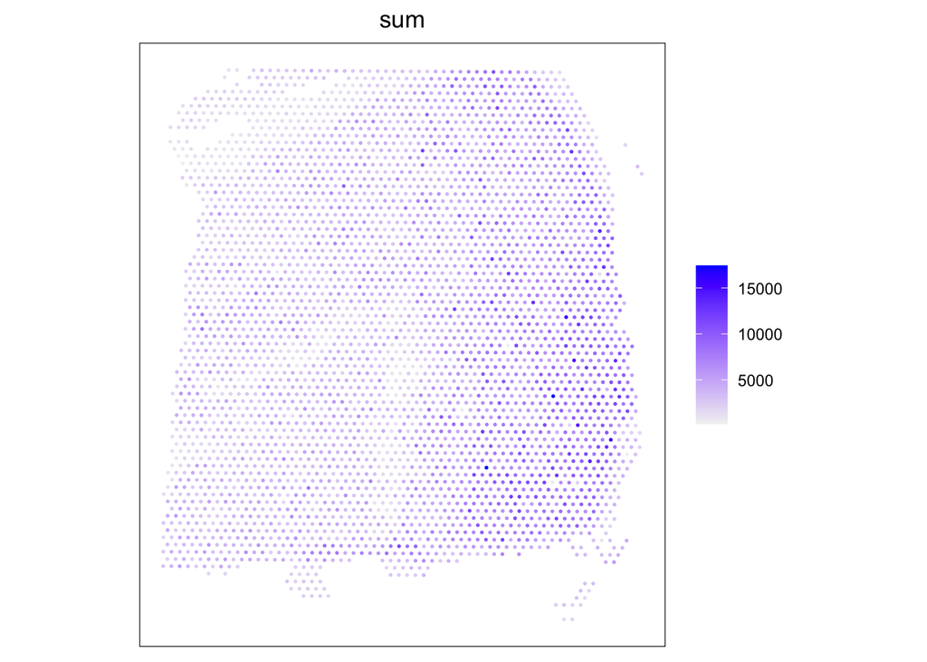

```r
spe <- addPerCellQC(spe) # should add MT subset here
plotSpots(spe, annotate = "sum")
```

First, do some exploration and filtering, similar to what has been done in the single-cell RNA-seq exercises. For example, you could calculate mitochondrial content (see `?addPerCellQC` on how to add subsets) for each spot, remove spots that have extreme values of either mitochondrial content, the number of reads or genes observed. Make a plot of the read counts versus the (estimated) number of cells per spot (see the `cell_count` column of `colData`). To save some computational time for some of the spatial measures below, you may also want to filter out genes that are lowly expressed or in few cells. Also, make a plot (use `ggspavis::plotSpots` or similar) of the MOBP gene and verify that it looks vaguely similar to that in Figure 1 of the Maynard paper (link above).

## Question 2. Different senses of variability

Compute, for each gene, a measure of *variability* (e.g., biological variability from `scran::modelGeneVar`) and a measure of *spatial variability* (e.g., Moran’s I, or use the `nnSVG` or `DESpace` packages). Make a plot of the (non-spatial) variability versus spatial variaibility (one point for each gene). Does this plot match your expectation (e.g., genes that are spatially variable should also be variable) ? Are there any outliers? Using `plotSpots()` or similar, plot a few interesting genes in terms of their concordance in variability (or lack thereof).

## Question 3. Explore spatially-aware dimensionality reduction

We’ve seen dimensionality reduction methods for (single cell) RNA-seq data and we could apply them ‘out of the box’ for spatial omics data. However, we may want to apply them in a spatially-aware manner, which ultimately means that we apply some level of smoothing to the data. For the LIBD Slice 151673 (data used above), produce a 2D projection (e.g., PCA, UMAP) without using any spatial information and produce another 2D projection using a spatially-aware approach (e.g., BANKSY). Ideally, colour your points according to the manual annotation (`reference` column of `colData`) to see what effect the smoothing has on the structure of your plots.

## Question 4. Spatially-aware clustering

Using the same dataset, cluster the spots into spatial “domains” (or clusters). You could use BayesSpace or BANKSY or simply cluster your spatially-aware low dimensional embeddings. Make a plot in spatial context coloured by cluster. Compare your clusters to the manual annotation using the adjusted Rand Index.

## Question 5. Find marker genes of the clusters

Using the clusters from Question 4, find marker genes for the clusters (e.g., using `findMarkers`, analogous to what one typically does with clusters from scRNA-seq data). Find a way to summarize the `findMarkers` (or similar analysis) results into a single number (e.g., overall P-value, or F-statistic representing the departure from the null of equal expression in all clusters) for each gene. Plot this value against the measure of spatial variability above (Question 2). Make a plot of a few genes (in spatial coordinates using `plotSpots()` or similar) to help you understand any similarity (or lack of similarity) between the differential-expression-statistics-linked-to-spatial-clusters (Question 5) and the spatial-variability statistics (Question 2).

As usual, upload your QMD and HTML to your exercise repository. Do not forget to use the template such that your graphics will be visible.